# Pet adoption prediction

Source: https://www.kaggle.com/datasets/rabieelkharoua/predict-pet-adoption-status-dataset Dataset Description: The Pet Adoption Dataset provides a comprehensive look into various factors that can influence the likelihood of a pet being adopted from a shelter. This dataset includes detailed information about pets available for adoption, covering various characteristics and attributes. Features (n=13): -PetID: Unique identifier for each pet. -PetType: Type of pet (e.g., Dog, Cat, Bird, Rabbit). -Breed: Specific breed of the pet. -AgeMonths: Age of the pet in months. -Color: Color of the pet. -Size: Size category of the pet (Small, Medium, Large). -WeightKg: Weight of the pet in kilograms. -Vaccinated: Vaccination status of the pet (0 - Not vaccinated, 1 - Vaccinated). -HealthCondition: Health condition of the pet (0 - Healthy, 1 - Medical condition). -TimeInShelterDays: Duration the pet has been in the shelter (days). -AdoptionFee: Adoption fee charged for the pet (in dollars). -PreviousOwner: Whether the pet had a previous owner (0 - No, 1 - Yes). -AdoptionLikelihood: Likelihood of the pet being adopted (0 - Unlikely, 1 - Likely).

```python
import pandas as pd
import numpy as np
import seaborn as sns
import matplotlib.pyplot as plt
%matplotlib inline
import scipy.stats as stats
from scipy.stats import skew, norm, probplot, boxcox, f_oneway

import warnings
warnings.filterwarnings("ignore")
```

```python
df = pd.read_csv("pet_adoption_data.csv")
```

```python
df["AdoptionLikelihood"].value_counts()
```

```
AdoptionLikelihood
0    1348
1     659
Name: count, dtype: int64
```

```python
del df['PetID']
```

```python
df.info()
```

```
<class 'pandas.core.frame.DataFrame'>
RangeIndex: 2007 entries, 0 to 2006
Data columns (total 12 columns):
 #   Column              Non-Null Count  Dtype
---  ------              --------------  -----
 0   PetType             2007 non-null   object
 1   Breed               2007 non-null   object
 2   AgeMonths           2007 non-null   int64
 3   Color               2007 non-null   object
 4   Size                2007 non-null   object
 5   WeightKg            2007 non-null   float64
 6   Vaccinated          2007 non-null   int64
 7   HealthCondition     2007 non-null   int64
 8   TimeInShelterDays   2007 non-null   int64
 9   AdoptionFee         2007 non-null   int64
 10  PreviousOwner       2007 non-null   int64
 11  AdoptionLikelihood  2007 non-null   int64
dtypes: float64(1), int64(7), object(4)
memory usage: 188.3+ KB
```

```python
df['AdoptionLikelihood'] = df['AdoptionLikelihood'].astype('category')
df['PetType'] = df['PetType'].astype('category')
df['Breed'] = df['Breed'].astype('category')
df['Color'] = df['Color'].astype('category')
df['Size'] = df['Size'].astype('category')
df['Vaccinated'] = df['Vaccinated'].astype('category')
df['HealthCondition'] = df['HealthCondition'].astype('category')
df['PreviousOwner'] = df['PreviousOwner'].astype('category')
```

```python
df.info()
```

```
<class 'pandas.core.frame.DataFrame'>
RangeIndex: 2007 entries, 0 to 2006
Data columns (total 12 columns):
 #   Column              Non-Null Count  Dtype
---  ------              --------------  -----
 0   PetType             2007 non-null   category
 1   Breed               2007 non-null   category
 2   AgeMonths           2007 non-null   int64
 3   Color               2007 non-null   category
 4   Size                2007 non-null   category
 5   WeightKg            2007 non-null   float64
 6   Vaccinated          2007 non-null   category
 7   HealthCondition     2007 non-null   category
 8   TimeInShelterDays   2007 non-null   int64
 9   AdoptionFee         2007 non-null   int64
 10  PreviousOwner       2007 non-null   category
 11  AdoptionLikelihood  2007 non-null   category
dtypes: category(8), float64(1), int64(3)
memory usage: 79.9 KB
```

```python
from sklearn.model_selection import train_test_split
import scipy.stats as stats
from scipy.stats import stats, norm, skew
import statsmodels.api as sm
from statsmodels.stats.outliers_influence import variance_inflation_factor
from sklearn import linear_model
from sklearn import metrics
from sklearn import datasets
```

```python
data=df.copy()
data.info()
```

```
<class 'pandas.core.frame.DataFrame'>
RangeIndex: 2007 entries, 0 to 2006
Data columns (total 12 columns):
 #   Column              Non-Null Count  Dtype
---  ------              --------------  -----
 0   PetType             2007 non-null   category
 1   Breed               2007 non-null   category
 2   AgeMonths           2007 non-null   int64
 3   Color               2007 non-null   category
 4   Size                2007 non-null   category
 5   WeightKg            2007 non-null   float64
 6   Vaccinated          2007 non-null   category
 7   HealthCondition     2007 non-null   category
 8   TimeInShelterDays   2007 non-null   int64
 9   AdoptionFee         2007 non-null   int64
 10  PreviousOwner       2007 non-null   category
 11  AdoptionLikelihood  2007 non-null   category
dtypes: category(8), float64(1), int64(3)
memory usage: 79.9 KB
```

```python
X = data.drop('AdoptionLikelihood',axis=1)
y = data['AdoptionLikelihood'].astype('int64')
```

```python
categorical_columns = ['PetType', 'Breed', 'Color','Size','Vaccinated','HealthCondition','PreviousOwner']
X = pd.get_dummies(X, columns=categorical_columns, drop_first=True)
```

```python
X_train, X_test, y_train, y_test =train_test_split(X, y, test_size=0.3, random_state=1)
print(X_train.shape, X_test.shape)
```

```
(1404, 22) (603, 22)
```

```python
from sklearn.tree import DecisionTreeClassifier
model = DecisionTreeClassifier(criterion='gini',class_weight={0:0.15,1:0.85},random_state=1)
```

```python
model.fit(X_train, y_train)
```

```
DecisionTreeClassifier(class_weight={0: 0.15, 1: 0.85}, random_state=1)
```

```python
def make_confusion_matrix(model,y_actual,labels=[1, 0]):
    y_predict = model.predict(X_test)
    cm=metrics.confusion_matrix( y_actual, y_predict, labels=[0, 1])
    df_cm = pd.DataFrame(cm, index = [i for i in ["Actual - No","Actual - Yes"]],
                  columns = [i for i in ['Predicted - No','Predicted - Yes']])
    group_counts = ["{0:0.0f}".format(value) for value in
                cm.flatten()]
    group_percentages = ["{0:.2%}".format(value) for value in
                         cm.flatten()/np.sum(cm)]
    labels = [f"{v1}\n{v2}" for v1, v2 in
              zip(group_counts,group_percentages)]
    labels = np.asarray(labels).reshape(2,2)
    plt.figure(figsize = (10,7))
    sns.heatmap(df_cm, annot=labels,fmt='')
    plt.ylabel('True label')
    plt.xlabel('Predicted label')
```

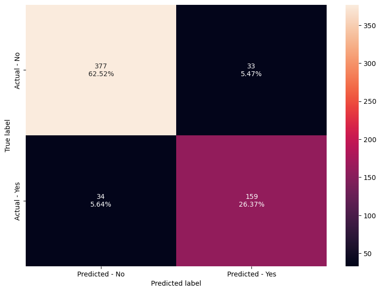

```python
make_confusion_matrix(model,y_test)
```

```python
y_train.value_counts(1)
```

```
AdoptionLikelihood
0    0.668091
1    0.331909
Name: proportion, dtype: float64
```

```python
def get_recall_score(model):
    pred_train = model.predict(X_train)
    pred_test = model.predict(X_test)
    print("Recall on training set : ",metrics.recall_score(y_train,pred_train))
    print("Recall on test set : ",metrics.recall_score(y_test,pred_test))
```

```python
get_recall_score(model)
```

```
Recall on training set :  1.0
Recall on test set :  0.8238341968911918
```

```python
#column_names = list(data.columns)
#column_names.remove('AdoptionLikelihood')
#feature_names = column_names
#print(feature_names)
```

```python
feature_names = X.columns.tolist()
print(feature_names)
```

[output not shown]

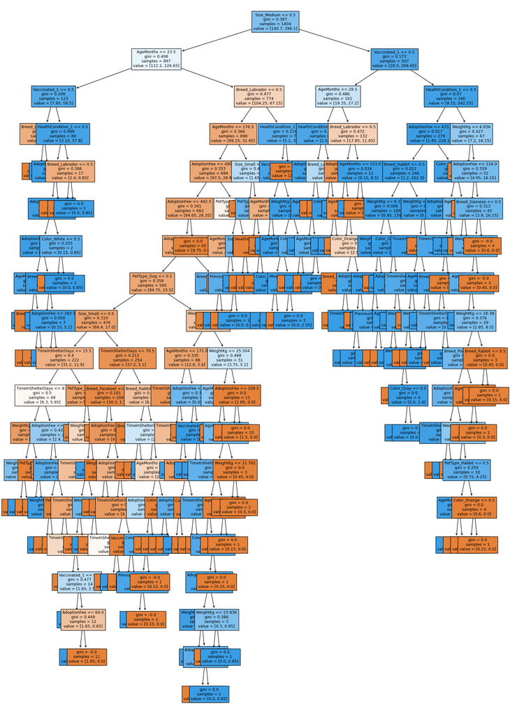

```python
from sklearn.model_selection import train_test_split
from sklearn import tree
from sklearn import metrics

plt.figure(figsize=(20,30))
out = tree.plot_tree(model,feature_names=feature_names,filled=True,fontsize=9,node_ids=False,class_names=None,)
for o in out:
     arrow = o.arrow_patch
     if arrow is not None:
        arrow.set_edgecolor('black')
        arrow.set_linewidth(1)
plt.show()
```

```python
print(tree.export_text(model,feature_names=feature_names,show_weights=True))
```

```
|--- Size_Medium <= 0.50
|   |--- AgeMonths <= 23.50
|   |   |--- Vaccinated_1 <= 0.50
|   |   |   |--- Breed_Labrador <= 0.50
|   |   |   |   |--- weights: [4.80, 0.00] class: 0
|   |   |   |--- Breed_Labrador >  0.50
|   |   |   |   |--- weights: [0.00, 1.70] class: 1
|   |   |--- Vaccinated_1 >  0.50
|   |   |   |--- HealthCondition_1 <= 0.50
|   |   |   |   |--- AdoptionFee <= 487.50
|   |   |   |   |   |--- AdoptionFee <= 471.00
|   |   |   |   |   |   |--- AdoptionFee <= 45.00
|   |   |   |   |   |   |   |--- AgeMonths <= 21.50
|   |   |   |   |   |   |   |   |--- weights: [0.00, 4.25] class: 1
|   |   |   |   |   |   |   |--- AgeMonths >  21.50
|   |   |   |   |   |   |   |   |--- Breed_Siamese <= 0.50
|   |   |   |   |   |   |   |   |   |--- weights: [0.15, 0.00] class: 0
|   |   |   |   |   |   |   |   |--- Breed_Siamese >  0.50
|   |   |   |   |   |   |   |   |   |--- weights: [0.15, 0.00] class: 0
|   |   |   |   |   |   |--- AdoptionFee >  45.00
|   |   |   |   |   |   |   |--- Breed_Siamese <= 0.50
|   |   |   |   |   |   |   |   |--- weights: [0.00, 46.75] class: 1
|   |   |   |   |   |   |   |--- Breed_Siamese >  0.50
|   |   |   |   |   |   |   |   |--- AdoptionFee <= 283.50
|   |   |   |   |   |   |   |   |   |--- weights: [0.00, 5.10] class: 1
|   |   |   |   |   |   |   |   |--- AdoptionFee >  283.50
|   |   |   |   |   |   |   |   |   |--- weights: [0.15, 0.00] class: 0
|   |   |   |   |   |--- AdoptionFee >  471.00
|   |   |   |   |   |   |--- Color_White <= 0.50
|   |   |   |   |   |   |   |--- weights: [0.15, 0.00] class: 0
|   |   |   |   |   |   |--- Color_White >  0.50
|   |   |   |   |   |   |   |--- weights: [0.00, 0.85] class: 1
|   |   |   |   |--- AdoptionFee >  487.50
|   |   |   |   |   |--- weights: [0.15, 0.00] class: 0
|   |   |   |--- HealthCondition_1 >  0.50
|   |   |   |   |--- Breed_Labrador <= 0.50
|   |   |   |   |   |--- weights: [2.40, 0.00] class: 0
|   |   |   |   |--- Breed_Labrador >  0.50
|   |   |   |   |   |--- weights: [0.00, 0.85] class: 1
|   |--- AgeMonths >  23.50
```

[output cut: 246 more lines]

```
|   |   |   |   |   |   |   |   |   |   |   |--- truncated branch of depth 4
|   |   |   |   |   |   |   |   |   |--- Breed_Poodle >  0.50
|   |   |   |   |   |   |   |   |   |   |--- AgeMonths <= 69.00
|   |   |   |   |   |   |   |   |   |   |   |--- weights: [0.15, 0.00] class: 0
|   |   |   |   |   |   |   |   |   |   |--- AgeMonths >  69.00
|   |   |   |   |   |   |   |   |   |   |   |--- weights: [0.30, 0.00] class: 0
|   |   |   |   |   |   |   |   |--- WeightKg >  26.38
|   |   |   |   |   |   |   |   |   |--- Breed_Rabbit <= 0.50
|   |   |   |   |   |   |   |   |   |   |--- weights: [0.30, 0.00] class: 0
|   |   |   |   |   |   |   |   |   |--- Breed_Rabbit >  0.50
|   |   |   |   |   |   |   |   |   |   |--- weights: [0.15, 0.00] class: 0
|   |   |   |   |   |   |--- WeightKg >  28.27
|   |   |   |   |   |   |   |--- weights: [0.45, 0.00] class: 0
|   |   |   |   |   |--- Breed_Siamese >  0.50
|   |   |   |   |   |   |--- weights: [0.60, 0.00] class: 0
```

```python
print (pd.DataFrame(model.feature_importances_, columns = ["Imp"], index = X_train.columns).sort_values(by = 'Imp', ascending = False))
```

```
                            Imp
AgeMonths          1.973755e-01
Breed_Labrador     1.876716e-01
Size_Medium        1.787058e-01
Vaccinated_1       1.006204e-01
AdoptionFee        7.483234e-02
WeightKg           6.553056e-02
TimeInShelterDays  6.197615e-02
HealthCondition_1  5.550308e-02
PetType_Cat        1.690114e-02
Size_Small         1.337220e-02
Color_Orange       1.276659e-02
PetType_Rabbit     8.234734e-03
Breed_Rabbit       7.967941e-03
PreviousOwner_1    3.920241e-03
Breed_Siamese      3.902347e-03
PetType_Dog        3.790749e-03
Breed_Parakeet     2.944976e-03
Breed_Poodle       2.749294e-03
Color_White        1.228072e-03
Color_Gray         6.248453e-06
Breed_Persian      5.116886e-17
Color_Brown        0.000000e+00
```

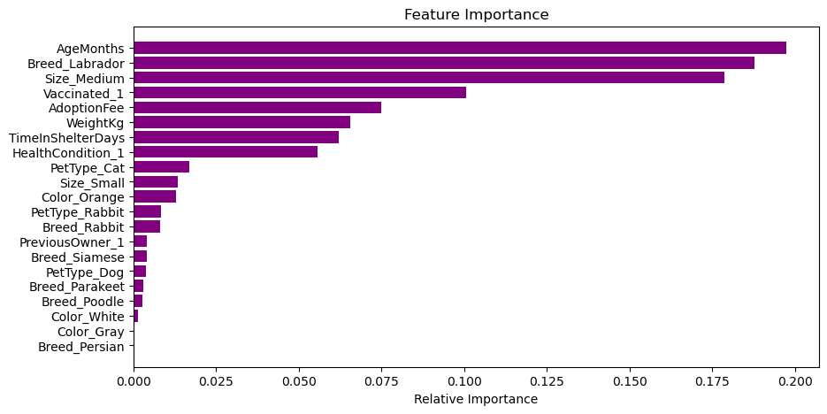

```python
importances = model.feature_importances_
indices = np.argsort(importances)
non_zero_mask = importances > 0
filtered_importances = importances[non_zero_mask]
filtered_indices = np.argsort(filtered_importances)

plt.figure(figsize=(10,5))
plt.title('Feature Importance')
plt.barh(range(len(filtered_indices)), filtered_importances[filtered_indices], color='purple', align='center')
plt.yticks(range(len(filtered_indices)), [feature_names[i] for i in np.where(non_zero_mask)[0][filtered_indices]])
plt.xlabel('Relative Importance')
plt.show()
```

```python
from sklearn.model_selection import GridSearchCV
```

```python
estimator = DecisionTreeClassifier(random_state=1,class_weight = {0:.15,1:.85})
parameters = {
            'max_depth': np.arange(15,27),
            'criterion': ['entropy','gini'],
            'splitter': ['best','random'],
            'min_impurity_decrease': [0.0001,0.001,0.001],
            'max_features': ['log2','sqrt']
             }

scorer = metrics.make_scorer(metrics.recall_score)

grid_obj = GridSearchCV(estimator, parameters, scoring=scorer,cv=5)
grid_obj = grid_obj.fit(X_train, y_train)

estimator = grid_obj.best_estimator_

estimator.fit(X_train, y_train)
```

```
DecisionTreeClassifier(class_weight={0: 0.15, 1: 0.85}, max_depth=15,
                       max_features='log2', min_impurity_decrease=0.001,
                       random_state=1)
```